# A2 - Anàlisi estadística I

# 4 Ser atleta influeix a la nota?

## 4.1 Anàlisi visual

Realitzem un petit anàlisi visual per tal d’orientar la pregunta.

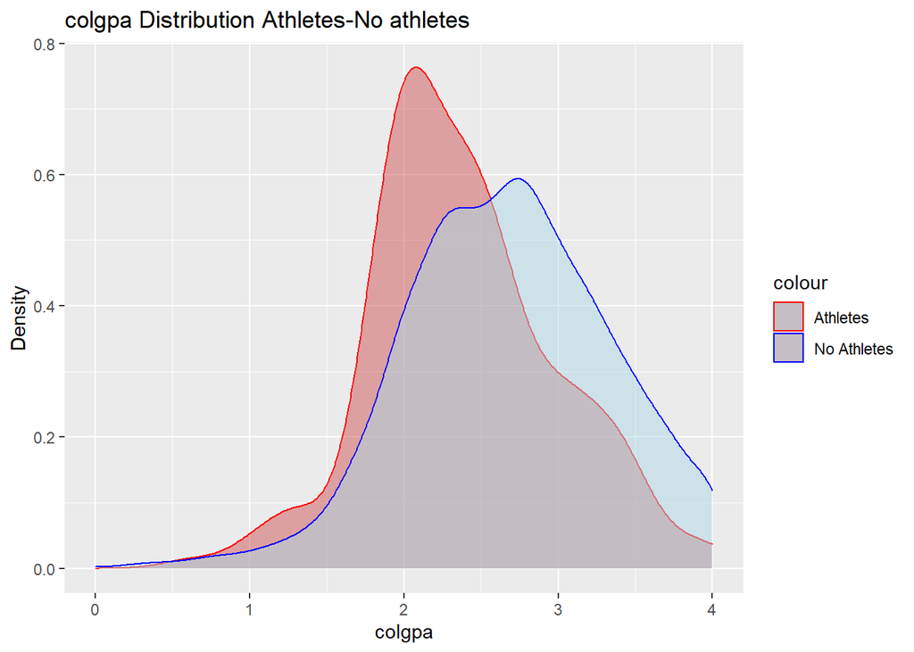

```r
#colgpa ath-noAth density ggplot
colgpaAthNotath.ggplot <- ggplot() +
  geom_density(aes(x = df.athletes$colgpa, color = 'Athletes'), alpha=.5, fill="indianred3") +
  geom_density(aes(x = df.noathletes$colgpa, color = 'No Athletes'), alpha=.5, fill="lightblue") +
  xlab("colgpa") + ylab("Density") + ggtitle('colgpa Distribution Athletes-No athletes') +
  theme(legend.position = 'right') +
  scale_color_manual(values = c('Athletes' = 'red', 'No Athletes' = 'blue'))
colgpaAthNotath.ggplot
```

Observem que hi ha una diferència en la distribució entre els alumnes que són atletes respecte a aquells que no ho són. Els alumnes que són atletes concentren la variable *‘colgpa’* sobre la zona del valor 2, mentre que aquells que no són atletes ho fan sobre la zona del valor 3.

## 4.2 Funció per al contrast de mitjanes

```r
tTest <- function( x1, x2, halternativa="twosided", C=95 ){

  mean1 <- mean(x1)
  mean2 <- mean(x2)
  n1 <- length(x1)
  n2 <- length(x2)
  sd1 <- sd(x1)
  sd2 <- sd(x2)
  alfa <- (1-C/100)

  #src: https://www.investopedia.com/terms/t/t-test.asp#:~:text=two%20sample%20sets.-,T%2DScore,validity%20of%20the%20null%20hypothesis.
  degreefreedom <- ( (sd1**2/n1 + sd2**2/n2)**2 ) / ( (sd1**2/n1)**2/(n1-1) + (sd2**2/n2)**2/(n2-1))
  t <- (mean1-mean2) / (sqrt( sd1**2/n1 + sd2**2/n2 ))

  if (halternativa=="twosided"){
    tcritical <- qt( alfa/2, degreefreedom, lower.tail=FALSE )
    pvalue <- pt( abs(t), degreefreedom, lower.tail=FALSE )*2
  }
  else if (halternativa=="<"){
    tcritical <- qt( alfa, degreefreedom, lower.tail=TRUE )
    pvalue <- pt( t, degreefreedom, lower.tail=TRUE )
  }
  else{ #">"
    tcritical <- qt( alfa, degreefreedom, lower.tail=FALSE )
    pvalue <- pt( t, degreefreedom, lower.tail=FALSE )
  }
  #Resultat en un named vector
  output <- c(alfa, mean1, mean2, t, tcritical, pvalue)
  names(output) <- c("alfa", "mean1", "mean2", "t", "tcritical", "pvalue")
  return (output)
}
```

## 4.3 Pregunta de recerca

La nota mitjana poblacional *‘colgpa’* dels alumnes que són atletes és inferior a la nota mitjana poblacional *‘colgpa’* de la resta d’alumnes?

## 4.4 Hipòtesi nul·la i l’alternativa

Un cop formulada la pregunta que desitgem respondre, cal determinar la hipòtesi nul·la i la hipòtesi alternativa.

$$H_0: \mu_{Athletes} = \mu_{Other}$$
$$H_1: \mu_{Athletes} < \mu_{Other}$$
La hipòtesi nul·la representa allò que desitgem provar, mentre que la hipòtesi alternativa, representa l’alternativa que oferim respecte a la hipòtesi nul·la.

## 4.5 Justificació del test a aplicar

Per saber quin tipus de test podem aplicar per resoldre la hipòtesi plantejada i les característiques de la mostra, hem de realitzar un petit estudi sobre el conjunt de dades.

```r
#New colgpa ath-no ath df
df.athletes.colgpa <- df.athletes$colgpa
df.noathletes.colgpa <- df.noathletes$colgpa

## Atheltes
df.athletes.nrow <- nrow(df.athletes)
print(paste("Athletes is a ", (df.athletes.nrow/(nrow(df))) *100, "% of the set"))
```

```
## [1] "Athletes is a  4.68938844573362 % of the set"
```

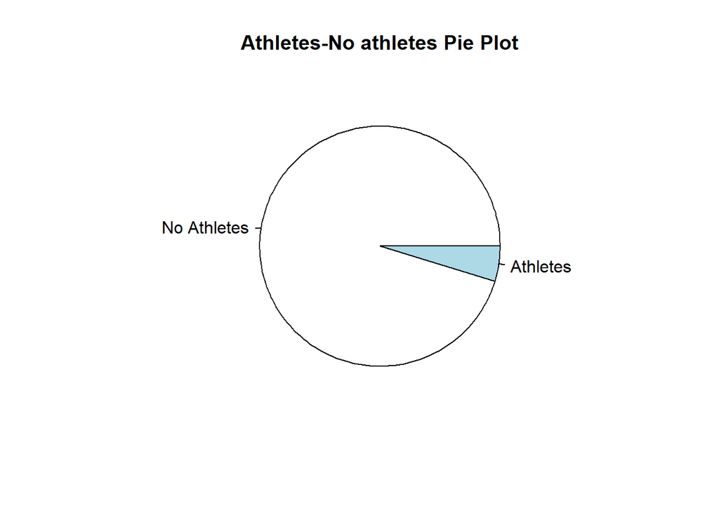

```r
pie(table(df$athlete), main="Athletes-No athletes Pie Plot",labels = c("No Athletes","Athletes"))
```

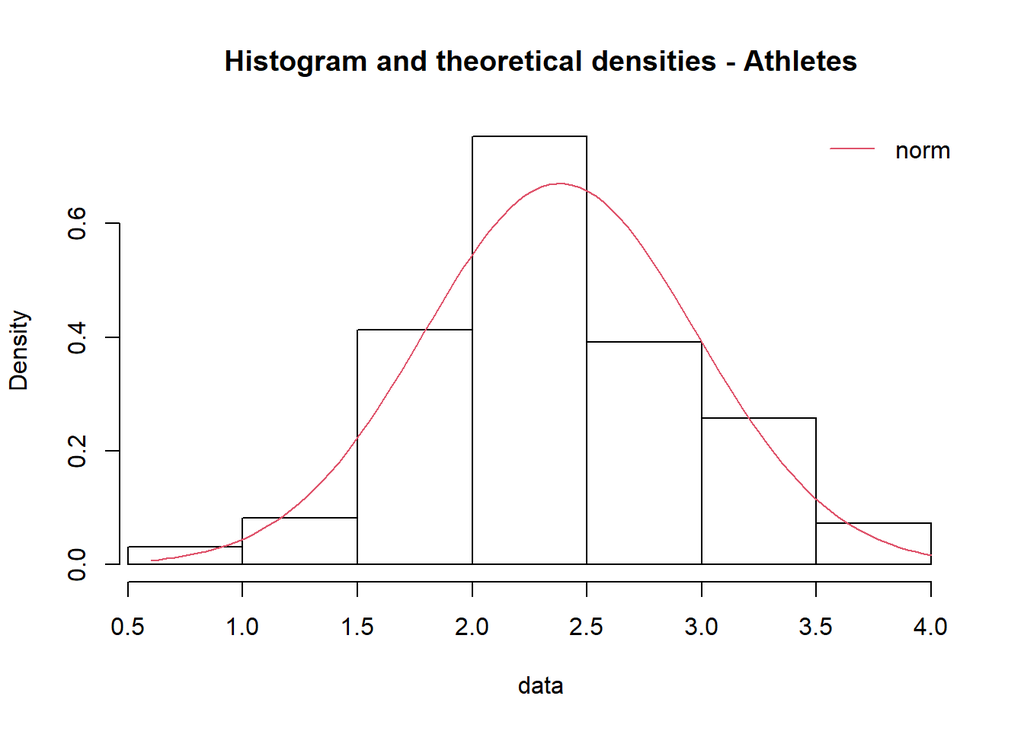

```r
#athletes norm
fit.norm.athletes.colgpa <- fitdist(df.athletes.colgpa, "norm")
denscomp(fit.norm.athletes.colgpa, main= "Histogram and theoretical densities - Athletes")
```

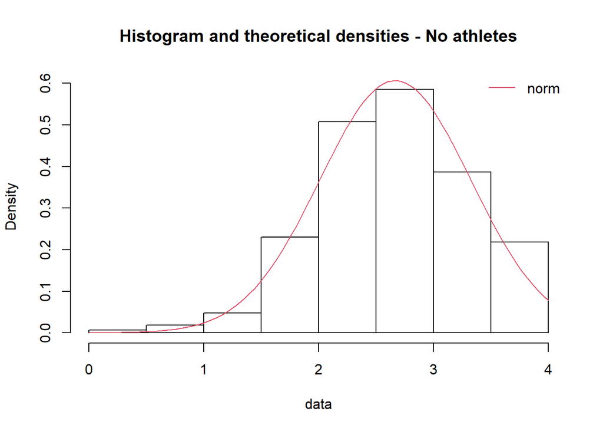

```r
#No atheltes
#No athletes norm
fit.norm.noathletes.colgpa <- fitdist(df.noathletes.colgpa, "norm")
denscomp(fit.norm.noathletes.colgpa, main= "Histogram and theoretical densities - No athletes")
```

## 4.6 Càlcul

Aplicarem la funció *tTest* creada anteriorment i realitzarem una comprovació amb la funció de R *t.test*.

```r
ttest.athNoAth.colgpa.95<-tTest( df.athletes.colgpa, df.noathletes.colgpa, "<", 95); ttest.athNoAth.colgpa.95
```

```
##          alfa         mean1         mean2             t     tcritical
##  5.000000e-02  2.382732e+00  2.667484e+00 -6.459086e+00 -1.651914e+00
##        pvalue
##  3.414476e-10
```

```r
t.test( df.athletes.colgpa, df.noathletes.colgpa, alternative="less", conf.level=0.95)
```

```
##
##  Welch Two Sample t-test
##
## data:  df.athletes.colgpa and df.noathletes.colgpa
## t = -6.4591, df = 216.76, p-value = 3.414e-10
## alternative hypothesis: true difference in means is less than 0
## 95 percent confidence interval:
##        -Inf -0.2119267
## sample estimates:
## mean of x mean of y
##  2.382732  2.667484
```

## 4.7 Interpretació del test

El *p valor* és una xifra que oscil·la entre 0 i 1, i que correspon a la probabilitat estadística que un valor sigui possible donat que la hipòtesi nul·la sigui certa. Aquest indicador, en cas de ser petit, indicarà que el valor de l’estadístic de contrast que hem observat tenia una probabilitat petita de sortir sota la hipòtesi nul·la i, per tant, rebutgem la hipòtesi nul·la. Per altra banda, en cas de ser gran, indicarà que era un valor bastant probable sota la hipòtesi nul·la i, en conseqüència, té sentit acceptar la hipòtesi nul·la. En el cas que ens ocupa, el valor p del test és molt petit. És per aquest motiu que, hem de refusar la hipòtesi nul·la, com a tal podem afirmar que la nota mitjana poblacional *‘colgpa’* dels atletes, és inferior a la resta dels altres alumnes.

# 5 Les dones tenen millor nota que els homes?

## 5.1 Anàlisi visual

Realitzem un petit anàlisi visual per tal d’orientar la pregunta.

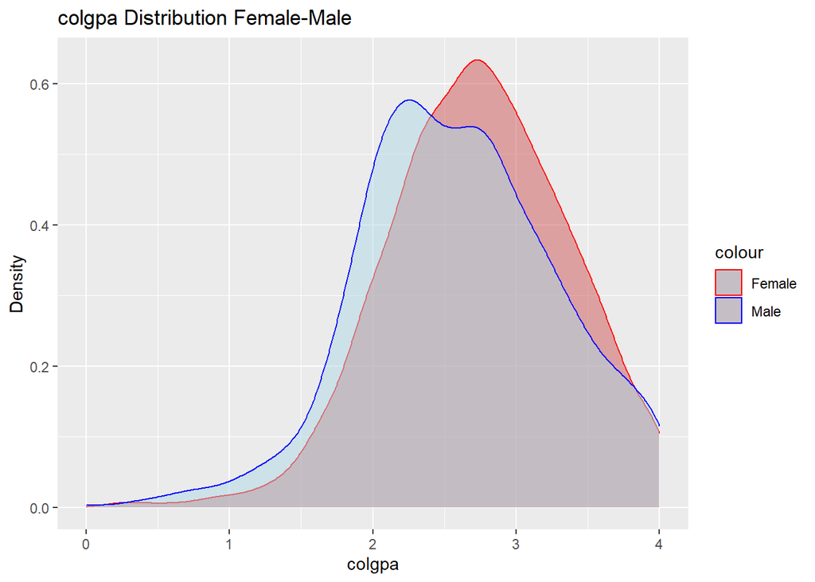

```r
#colgpa female-male density ggplot
colgpaFemaleMale.ggplot <- ggplot() +
  geom_density(aes(x = df.female$colgpa, color = 'Female'), alpha=.5, fill="indianred3") +
  geom_density(aes(x = df.male$colgpa, color = 'Male'), alpha=.5, fill="lightblue") +
  xlab("colgpa") + ylab("Density") + ggtitle('colgpa Distribution Female-Male') +
  theme(legend.position = 'right') +
  scale_color_manual(values = c('Female' = 'red', 'Male' = 'blue'))
colgpaFemaleMale.ggplot
```

```r
#Densities comparation - real and theoretical
df.female.colgpa <- df.female$colgpa
df.female.nrow <- nrow(df.female); df.female.nrow
```

```
## [1] 1860
```

```r
df.male.colgpa <-df.male$colgpa
df.male.nrow <- nrow(df.male); df.male.nrow
```

```
## [1] 2277
```

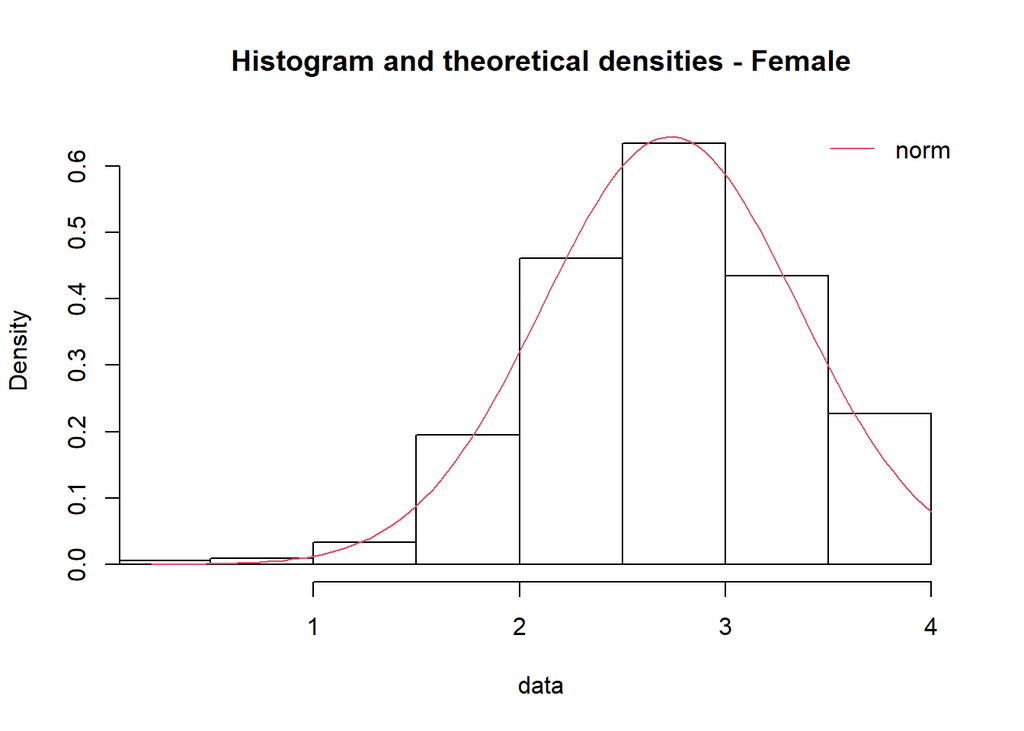

```r
#Female
fit.norm.female.colgpa <- fitdist(df.female.colgpa, "norm")
denscomp(fit.norm.female.colgpa, main= "Histogram and theoretical densities - Female")
```

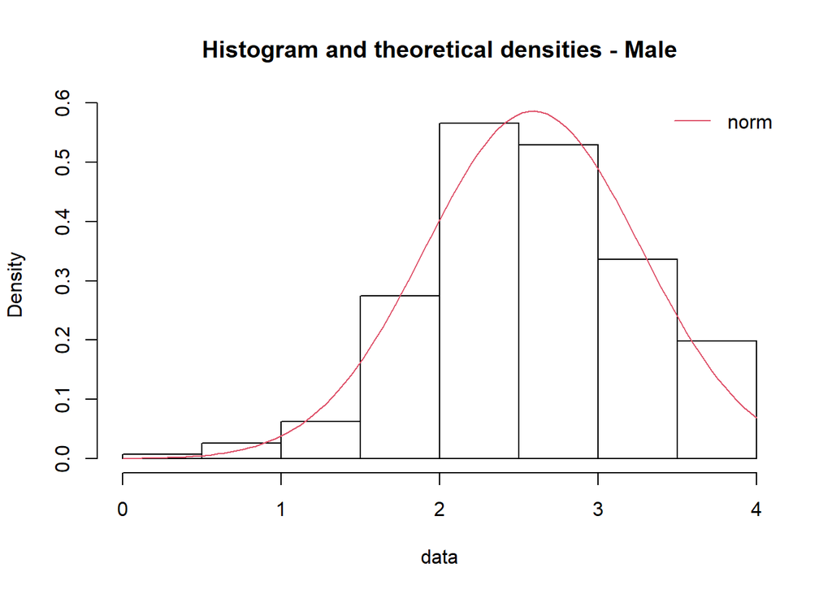

```r
#Male
fit.norm.male.colgpa <- fitdist(df.male.colgpa, "norm")
denscomp(fit.norm.male.colgpa, main= "Histogram and theoretical densities - Male")
```

Observem que la distribució de les dues mostres són molt similars amb una tendènia simètrica en els dos casos. En el cas de les dones el valor central de la variable *‘colgpa’* es troba sobre el valor 2.75 mentre que en el cas dels homes sobre el 2.25.

## 5.2 Funció

Es farà servir la funció realitzada a l’apartat 4.2. Justificació a l’apartat 5.5.

## 5.3 Pregunta de recerca

La nota mitjana poblacional ‘colgpa’ dels alumnes que són dones és superior a la nota mitjana poblacional ‘colgpa’ dels alumnes homes?

## 5.4 Hipòtesi nul·la i l’alternativa

Un cop formulada la pregunta que desitgem respondre, cal determinar la hipòtesi nul·la i la hipòtesi alternativa.

$$H_0: \mu_{Female} = \mu_{Male}$$
$$H_1: \mu_{Female} > \mu_{Male}$$

## 5.5 Justificació del test a aplicar

A través de l’anàlisi visual que hem realitzat anteriorment, podem observar que disposem de dues distribucions de tendència simètrica. A la vegada, aquesta mostra pot ser considerada com a una mostra de mida gran donat el nombre de registres que disposem en els dos casos. Mitjançant l’aplicació del teorema del límit central, per una mostra de mida gran, aquesta es comporta com a una distribució normal. Per dur a terme la comprovació total d’aquest fet, hem comparat la distribució de cada una de les dues mostres (female i male) amb la distribució de densitat teòrica d’una distribució de tipus normal, i veiem en els dos casos encaixa de forma bastant precisa. Així doncs, estaríem parlant de dues distribucions de tipus normal. El test aplicat a la secció anterior, hem utilitzat la funció *qt*, ja que havíem tingut en compte que treballàvem sobre una distribució t de Student. En el cas actual hauríem de fer servir *qnorm*, que ens entrega el quantil d’una distribució de tipus normal especificant una densitat acumulada concreta. Tot i això, la diferència dels resultats obtinguts amb la funció *qt* respecte *qnorm*, serien molt similars, és per aquest motiu que s’acceptaria fer servir *qt* en lloc de *qnorm*, i com a tal, útil la funció anterior pel cas actual.

## 5.6 Càlcul

Aplicarem la funció *tTest* creada anteriorment i realitzarem una comprovació amb els la funció de R *t.test*.

```r
ttest.femaleMale.colgpa.95<-tTest( df.female.colgpa, df.male.colgpa, ">", 95); ttest.femaleMale.colgpa.95
```

```
##         alfa        mean1        mean2            t    tcritical       pvalue
## 5.000000e-02 2.733016e+00 2.589693e+00 7.078735e+00 1.645227e+00 8.521971e-13
```

```r
t.test( df.female.colgpa, df.male.colgpa, alternative="greater", conf.level=0.95)
```

```
##
##  Welch Two Sample t-test
##
## data:  df.female.colgpa and df.male.colgpa
## t = 7.0787, df = 4087.4, p-value = 8.522e-13
## alternative hypothesis: true difference in means is greater than 0
## 95 percent confidence interval:
##  0.1100126       Inf
## sample estimates:
## mean of x mean of y
##  2.733016  2.589693
```

## 5.7 Interpretació del test

Observant els resultats obtinguts en el càlcul del test a l’apartat anterior, podem visualitzar que el valor p és molt petit i inferior al nivell de significació. És per aquest motiu, que hem de refusar la hipòtesi nul·la. Per tant, afirmar que la hipòtesi alternativa és certa. La nota mitjana poblacional *‘colgpa’* de les alumnes dones és superior al dels alumnes homes.

# 6 Hi ha diferències a la nota segons la raça?

## 6.1 Anàlisi visual

Realitzem un petit anàlisi visual per tal d’orientar la pregunta.

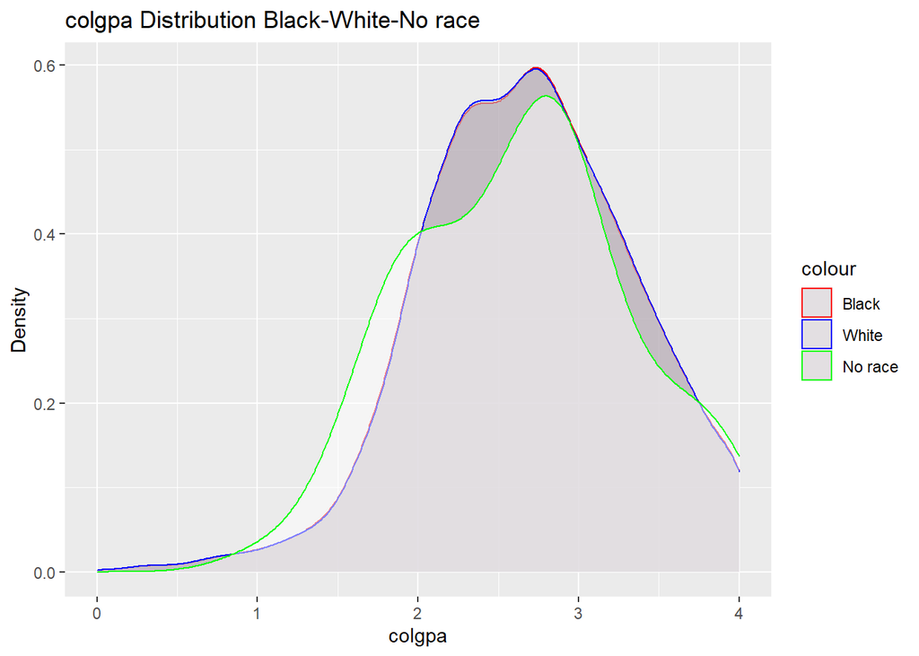

```r
#colgpa black-white-noRace density ggplot
colgpaBlackWhiteNorace.ggplot <- ggplot() +
  geom_density(aes(x = df.black$colgpa, color = 'Black'), alpha=.5, fill="indianred3") +
  geom_density(aes(x = df.white$colgpa, color = 'White'), alpha=.5, fill="lightblue") +
  geom_density(aes(x = df.noRace$colgpa, color = 'No race'), alpha=.5, fill="white") +
  xlab("colgpa") + ylab("Density") + ggtitle('colgpa Distribution Black-White-No race') +
  theme(legend.position = 'right') +
  scale_color_manual(values = c('Black' = 'red', 'White' = 'blue', 'No race' = 'green'))
colgpaBlackWhiteNorace.ggplot
```

```r
#Densities comparation - real and theoretical
df.black.colgpa <- df.black$colgpa
df.black.nrow <- nrow(df.black); df.black.nrow
```

```
## [1] 3908
```

```r
df.white.colgpa <-df.white$colgpa
df.white.nrow <- nrow(df.white); df.white.nrow
```

```
## [1] 3829
```

```r
df.noRace.colgpa <-df.noRace$colgpa
df.noRace.nrow <- nrow(df.noRace); df.noRace.nrow
```

```
## [1] 79
```

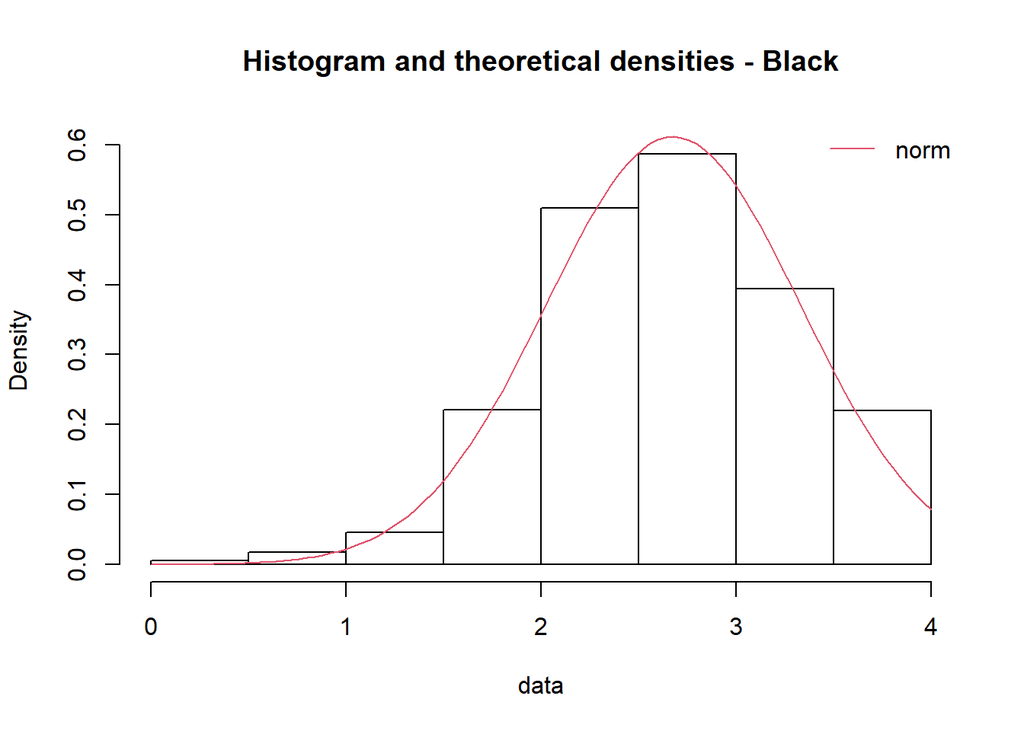

```r
#Black
fit.norm.black.colgpa <- fitdist(df.black.colgpa, "norm")
denscomp(fit.norm.black.colgpa, main= "Histogram and theoretical densities - Black")
```

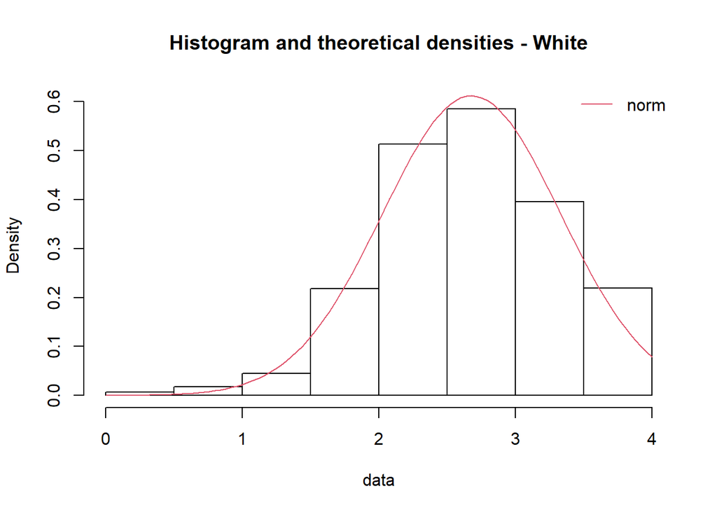

```r
#White
fit.norm.white.colgpa <- fitdist(df.white.colgpa, "norm")
denscomp(fit.norm.white.colgpa, main= "Histogram and theoretical densities - White")
```

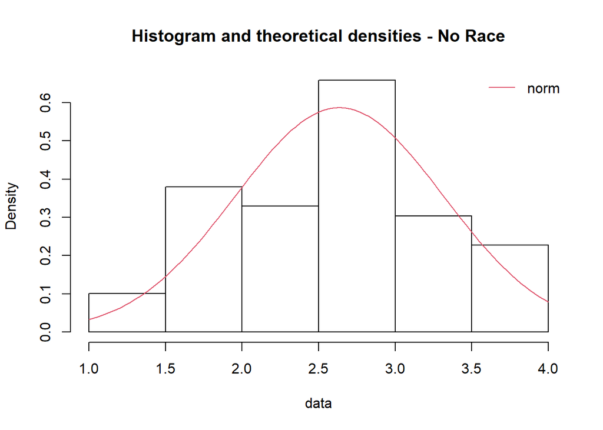

```r
#No race
fit.norm.noRace.colgpa <- fitdist(df.noRace.colgpa, "norm")
denscomp(fit.norm.noRace.colgpa, main= "Histogram and theoretical densities - No Race")
```

En primer lloc, observem que en aquest cas d’anàlisi disposem de tres mostres en comptes de dues. La distribució de les tres mostres són molt similars amb una tendència simètrica en els tres casos. En el cas de les distribucions *‘white’* i *‘black’*, aquestes són pràcticament calcades amb un punt central sobre el valor 2.75. Pel que fa al cas de la distribució que no correspon ni a gent blanca ni negra, aquest disposa d’un punt central amb un valor una mica major que estaria sobre el 2.8. El que podem apreciar, és que aquesta tercera mostra, és en qüestions de volum és molt més reduïda (79 registres) respecte al volum de les altres dues que quasi estan formades per 4000 registres. En aquest sentit, respecte al teorema del límit central, totes tres serien considerades una mostra gran, i com a tal tindrien un comportament seguint una distribució de tipus normal. Les dues primeres, realitzant la comparativa real respecte la densitat teòrica, veiem que encaixen força bé, mentre que la tercera pot quedar una mica més allunyada. Un dels motius pel qual pot passar aquest fet, és degut a la petita mida d’aquesta mostra. És per aquest motiu, que decidirem obviar aquesta mostra a la següent hipòtesi a dur a terme.

## 6.2 Funció

Es farà servir la funció realitzada a l’apartat 4.2. Justificació a l’apartat 6.5.

## 6.3 Pregunta de recerca

Aquest pregunta es possible realitzar-la en els dos sentits, la nota mitjana poblacional *‘colgpa’* dels alumnes negres és superior a la nota mitjana poblacional *‘colgpa’* dels alumnes blancs, o a la inversa. Això és donat a que realment volem saber si té algun tipus relació la raça o no. Per tant, totes dues preguntes serien valides.

## 6.4 Hipòtesi nul·la i l’alternativa

Un cop formulada la pregunta que desitgem respondre, cal determinar la hipòtesi nul·la i la hipòtesi alternativa.

$$H_0: \mu_{Black} = \mu_{White}$$
$$H_1: \mu_{Black} > \mu_{White}$$

## 6.5 Justificació del test a aplicar

Com hem comentat a l’apartat 6.1, estem parlant de dues distribucions de tendència simètrica, d’una mida gran i que aplicant el teorema del límit central segueixen una distribució de tipus normal. A més a més, hem realitzat la comparativa real respecte la densitat teòrica i veiem que encaixen força bé en aquesta. Per tant, tal com hem explicat anteriorment a l’apartat 5.5, podem aplicar la mateixa funció de test creada a l’apartat 4.2, donat que el resultat obtingut mitjançant *qnorm* i *qt* és molt similar.

## 6.6 Càlcul

Aplicarem la funció *tTest* creada anteriorment i realitzarem una comprovació amb la funció de R *t.test*.

```r
ttest.blackWhite.colgpa.95<-tTest( df.black.colgpa, df.white.colgpa, ">", 95); ttest.blackWhite.colgpa.95
```

```
##        alfa       mean1       mean2           t   tcritical      pvalue
##  0.05000000  2.67748720  2.67835988 -0.05881459  1.64505072  0.52344935
```

```r
t.test( df.black.colgpa, df.white.colgpa, alternative="greater", conf.level=0.95)
```

```
##
##  Welch Two Sample t-test
##
## data:  df.black.colgpa and df.white.colgpa
## t = -0.058815, df = 7732.1, p-value = 0.5234
## alternative hypothesis: true difference in means is greater than 0
## 95 percent confidence interval:
##  -0.02528162         Inf
## sample estimates:
## mean of x mean of y
##  2.677487  2.678360
```

## 6.7 Interpretació del test

Observant els resultats obtinguts en el càlcul del test a l’apartat anterior, podem veure que el valor p dins d’un rang de 0 a 1, és bastant gran i major que el nivell de significació. És per aquest motiu, que no podem rebutjar la hipòtesi nul·la. Així doncs, no podem afirmar que la nota mitjana poblacional *‘colgpa’* dels alumnes negres sigui superior a la nota mitjana poblacional *‘colgpa’* dels alumnes blancs. De fet, si retornem a la comparativa visual de l’apartat 6.1, podem veure que la distribució dels valors és gairebé igual en una mosta de 4000 registres en els dos casos.

# 7 Proporció d’atletes

## 7.1 Anàlisi visual

Realitzem un petit anàlisi visual per tal d’orientar la pregunta.

```r
#dfAth and dfNoath nrows
df.athletes.nrow <- nrow(df.athletes); df.athletes.nrow
```

```
## [1] 194
```

```r
df.noathletes.nrow <- nrow(df.noathletes); df.noathletes.nrow
```

```
## [1] 3943
```

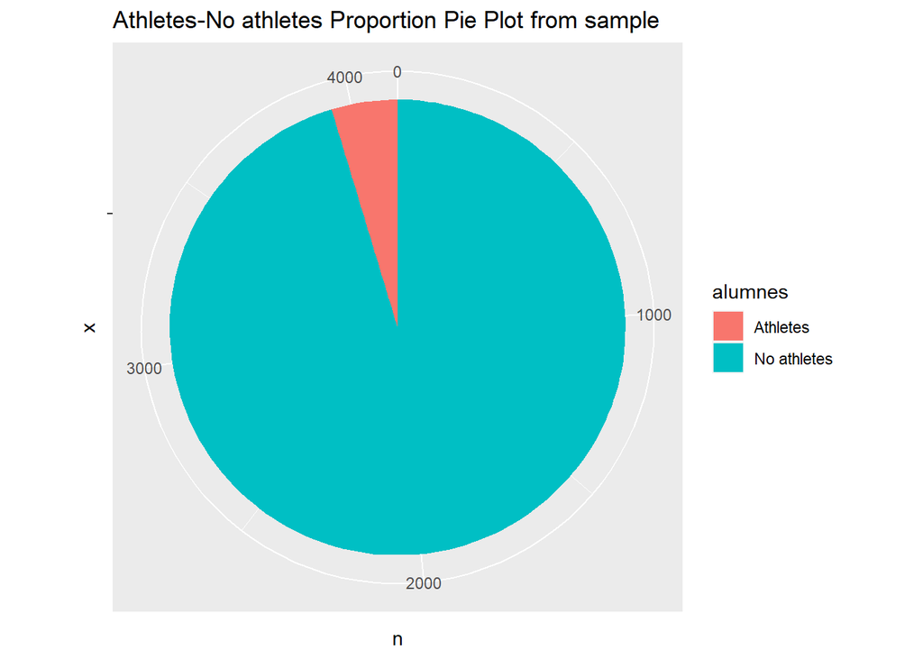

```r
#Ath-NoAth pie plot
df.athNoAth <- data.frame( alumnes=c("Athletes","No athletes"), n=c(nrow(df.athletes), nrow(df.noathletes)))
ggplot.pie.athNoAth <-ggplot(df.athNoAth) +
  aes( x="", y=n, fill= alumnes) +
  geom_bar(stat="identity", width=1) +
  coord_polar("y", start=0)+
  labs(title = "Athletes-No athletes Proportion Pie Plot from sample")
ggplot.pie.athNoAth
```